# NCAA & MLB Stats vs Win%

Cameron Lane

01/14/2024

## Introduction

In this report, I will analyze the relationships between baseball teams’ collective batting and pitching statistics with their regular season Win Percentage (**Win%**). This analysis will be conducted for both Major League Baseball and NCAA Division 1 Baseball.

## Load Necessary Packages and Function Files

```r
library(dplyr)
library(ggplot2)
library(knitr)
library(kableExtra)
library(baseballr)
source("MLB_Teams.R")
source("MLB_Batting_Data.R")
source("MLB_Pitching_Data.R")
source("NCAA_Major_Teams.R")
source("NCAA_Schedule_to_Record.R")
source("NCAA_Batting_Data.R")
source("NCAA_Pitching_Data.R")
```

NCAA & MLB Baseball data was collected using Bill Petti’s *baseballr* package available on Github at https://github.com/BillPetti/baseballr.

## Collect, Parse, and Extrapolate Data

### Call and Parse MLB Team Data

```r
MLB_Teams <- get_MLB_teams()
MLB_Batting_Data <- get_MLB_batting_data(MLB_Teams)
MLB_Pitching_Data <- get_MLB_pitching_data(MLB_Teams)
```

The baseballr package allows us to pull the League Standings as well as Team Batting and Pitching Statistics in a given year through the API provided by https://www.baseball-reference.com/.

The League Standings API call provides each league’s standings including each team’s record from which every team’s **Win%** is calculated.

The Team Stats API call for batting provides the cumulative team batting statistics for a single team of a regular season. This data included each team’s On Base Plus Slugging% (**OPS**), but Weighted On Base Average (**wOBA**) had to be calculated using the *woba_plus* function from the *baseballr* library in the following line of code from *MLB_Batting_Data.R*:

```r
MLB_Batting_wOBA <- woba_plus(Team_Batting_Stats_Parsed)
```

The Team Stats API call for pitching provides the cumulative team pitching statistics for a single team of a regular season. This data included each team’s Earned Run Average (**ERA**) and Walks and Hits per Inning Pitched (**WHIP**), but Fielding Independent Pitching (**FIP**) and opponent Weighted On Base Average (**wOBA Against**) had to be calculated using the *fip_plus* function from the *baseballr* library in the following line of code from *MLB_Pitching_Data.R*:

```r
MLB_Pitching_FIP <- fip_plus(Team_Pitching_Stats_Parsed)
```

The functions for the API calls and data parsing for each of the used data frames can be found in the following files: - MLB Teams: MLB_Teams.R - MLB Batting Data: MLB_Batting_Data.R - MLB Pitching Data: MLB_Pitching_Data.R

### Call and Parse NCAA Team Data

```r
NCAA_Teams <- get_NCAA_teams()
NCAA_Batting_Data <- get_NCAA_batting_data(NCAA_Teams)
NCAA_win_loss <- get_NCAA_win_loss(NCAA_Batting_Data)
NCAA_Pitching_Data <- get_NCAA_pitching_data(NCAA_Teams)
```

The NCAA Pitching and Batting Data proved more difficult for a few reasons. First, the NCAA has hundreds of baseball programs across Divisions I, II, and III. Second, baseball-reference API does not provide rankings, only team schedules with results. Finally, the API only provides player data, not team-level data for a given season.

To address the multiplicity of teams, I selected only those teams in 8 of the most successful conferences, including all of the Power 5 (Big 12, SEC, ACC, Big 10, and PAC-12).

From this list of teams, I called each team’s 2023 schedule and used the game results to tally wins and losses to calculate the team’s **Win%**.

Finally, I used the list of teams to iteratively call the API to draw player batting and pitching data. I cut down the batting data to each team’s starting lineup (9 players with the most Plate Appearances) and summarized each batting statistic. **wOBA** was calculated using *woba_plus* as with the MLB data. Unlike the MLB data, **OPS** was not included, so I calculated it by team with the equation:

$OPS = OBP + SLG$

The pitching data did not need to be narrowed down to the starting 9, so I simply summarized the data by team and found each team’s **FIP** and **wOB Against** using the fip_plus function. However, **ERA** and **WHIP** data were not (and mathematically could not) be included by team, so I calculated them with the following equations:

$ERA = (9*R)/IP$

$WHIP = (BB+H)/IP$

After this was done, I had sufficient sabermetric batting and pitching data for every MLB team and over 90 major NCAA baseball programs for the 2023 regular season. I then merged all this data in two data frames for easier correlation analysis and plotting.

```r
MLB_Batting_vs_WPer <- merge(MLB_Teams, MLB_Batting_Data)
MLB_Averages_vs_WPer <- merge(MLB_Batting_vs_WPer, MLB_Pitching_Data)

NCAA_Batting_vs_WPer <- merge(NCAA_Batting_Data, NCAA_win_loss)
NCAA_Averages_vs_WPer <- merge(NCAA_Batting_vs_WPer, NCAA_Pitching_Data)
```

## Analyze and Plot Stats vs. Win%

### Find Correlation between Metrics and Win%

```r
MLB_OPS_cor <- cor(MLB_Averages_vs_WPer$OPS, MLB_Averages_vs_WPer$win_loss)
NCAA_OPS_cor <- cor(NCAA_Averages_vs_WPer$avg_OPS, NCAA_Averages_vs_WPer$win_loss)
```

First, I used the **OPS** and **wOBA** and **Win%** of every team across both the MLB and NCAA to determine the correlation between each statistic and Win% in the NCAA & MLB. An Example of the code for **OPS** vs **Win%** is included above.

```r
MLB_ERA_cor <- cor(MLB_Averages_vs_WPer$ERA, MLB_Averages_vs_WPer$win_loss)
NCAA_ERA_cor <- cor(NCAA_Averages_vs_WPer$ERA, NCAA_Averages_vs_WPer$win_loss)
```

Then I used **ERA**, **FIP**, **WHIP**, and **wOBA Against** to find their correlation with **Win%**.

### Plot Batting Metrics vs Win%

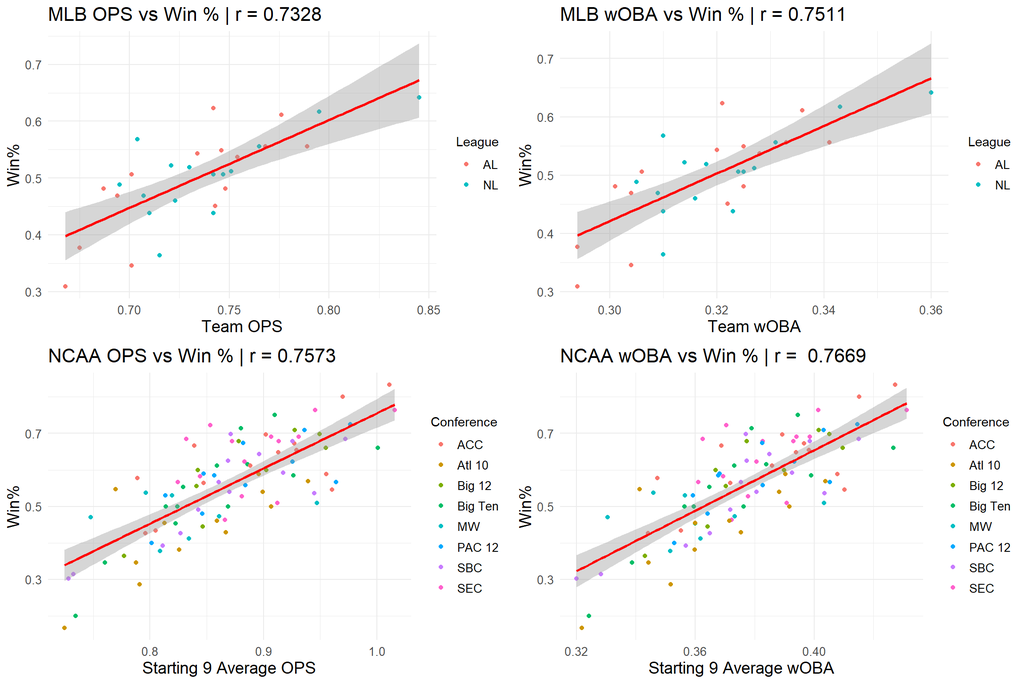

When plotting the batting data, we can see a respectable correlation between **OPS**, **wOBA**, and **Win%**. We can also see that **wOBA** has a slightly stronger correlation in both the NCAA & MLB because it is a more advanced metric weighted across league averages.

### Plot Pitching Metrics vs Win%

Because I have four metrics for pitching data, I broke the plots up into two squares: one for **ERA** and **WHIP**, which are not advanced metrics, and one for **FIP** and **wOBA Against**.

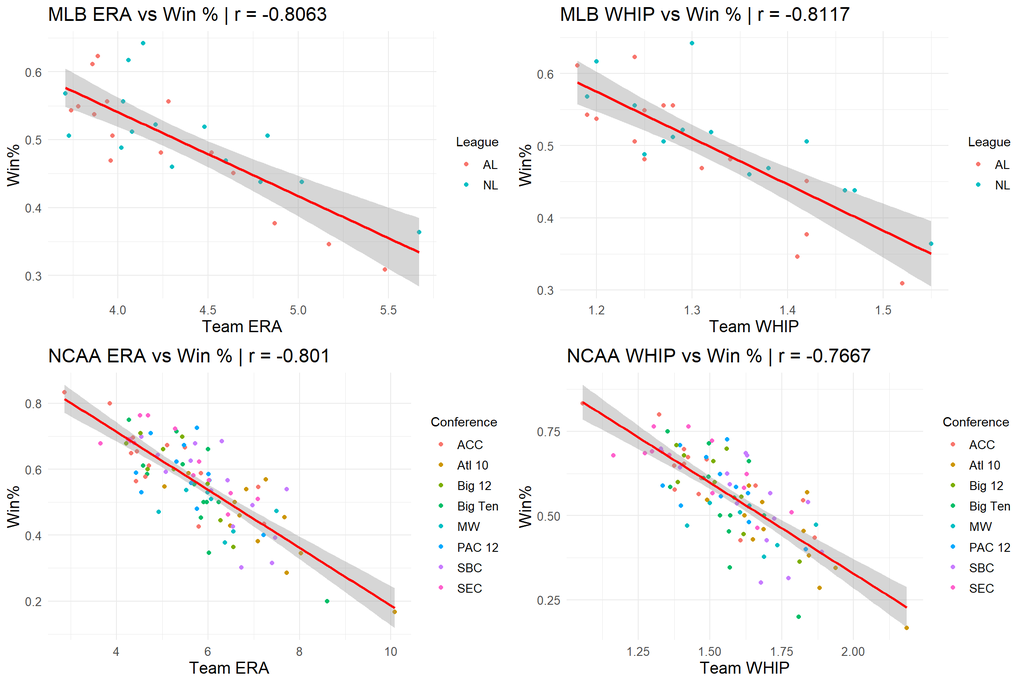

First, we plot the non-advanced metrics, **ERA** and **WHIP**. We see an even more significant correlation between these metrics and **Win%** than the batting metrics across both the NCAA & MLB.

Then, we plot the advanced metrics, **FIP** and **wOBA Against**.

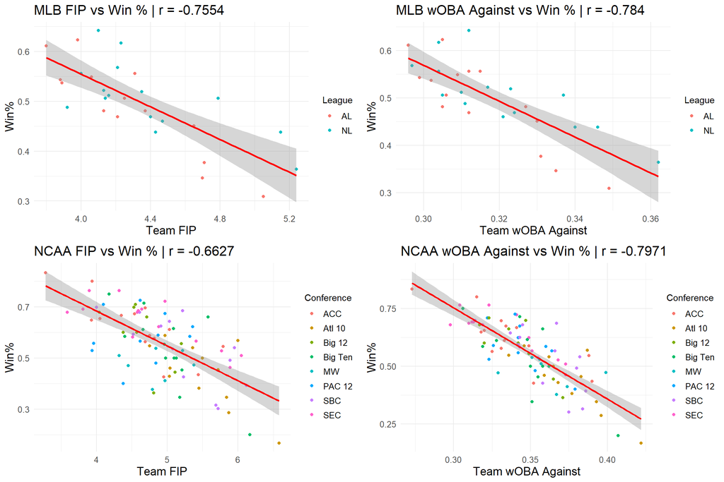

We continue to see strong correlations between these metrics and **Win%** with a notably weaker correlation for NCAA **FIP**. NCAA fielding can be notoriously poor (sometimes it’s a comedy of errors) which is likely why this metric doesn’t hold up as well.

## Correlation Table

| Level | OPS | wOBA | ERA | WHIP | FIP | wOBA Against |
| --- | --- | --- | --- | --- | --- | --- |
| MLB | 0.7328 | 0.7511 | -0.8063 | -0.8117 | -0.7554 | -0.7840 |
| NCAA | 0.7573 | 0.7669 | -0.8010 | -0.7667 | -0.6627 | -0.7971 |

## Conclusions

Every metric correlated significantly with **Win%** in both the NCAA & MLB. as expected. Overall, it appears that pitching performance is slightly more closely related to a team’s success in the regular season.